# Final Project

## Subsetting

### Subsetting using the $ sign

When we want to work with a specific portion of a data set instead of the whole thing, we can subset it in different ways. The easiest way to subset a column out of a data set is to use the “$” sign in this fashion:

```r
# To specify a column we first type the name of the data frame we're referring to, then the $ sign, and then the name of the column like this:
width <- ginkgo$max_width
```

When typing the data frame name followed by the “$” sign, R will often display a list of column names for you to choose from, which is very convenient.

We can also use this method when trying to analyze a certain column without subsetting it. For example, if we want to find the mean of the “maxwidth” column of the ginkgo data frame, we could subset out the column and then find the average of the subset *or* we can simply use “$” sign in the mean() command like this:

```r
mean(ginkgo$max_width)
```

```
## [1] 74.33823
```

### Subsetting by position

When we know the order of our columns or rows, we can also use numbers to describe the subset of data we’d like to specify. If we’re not sure of the order of our columns, we can use the names() function to tell us:

```r
names(ginkgo)
```

```
## [1] "ï..site_id"     "seeds_present"  "max_width"      "max_depth"
## [5] "notch_depth"    "petiole_length"
```

Now that we know the names of our columns, we can specify which columns we want to subset based on the number associated with that column. To subset a data frame using the numbers associated with rows and columns, we use brackets following these rules:

Within the brackets there are two values, the row number (before the comma) and the column number (after the comma).

When we only want to specify a single row in a data frame, we would put the row number followed by a comma and no column number (ex. [2,] or [5,]).

If we only want to specify a column and not a row, we would leave a blank where the row number would be, then put a comma and our column number (ex. [,1] or [,7]).

If we want to specify a single value (an intersection between a row and column), we can specify both a row and a column that correspond with our desired value (ex. [2,7] or [4,2]).

Here are some examples using our ginkgo data:

```r
# Subsetting just column 3 of our ginkgo data
max_width <- ginkgo[,3]
# The head() function shows us the top 6 rows of a data frame and can be useful
  #to check if subsetting worked without seeing the entire subset of data
head(max_width)
```

```
## [1] 71 64 55 62 65 70
```

```r
# Subsetting just row 1 of our ginkgo data
row_1 <- ginkgo[1,]
row_1
```

```
##   ï..site_id seeds_present max_width max_depth notch_depth petiole_length
## 1       7719         FALSE        71        40           0             30
```

```r
# Subsetting a specific element in row 2, column 3
row2_column3 <- ginkgo[2,3]
row2_column3
```

```
## [1] 64
```

### Conditional subsetting

The final way we can subset is conditional subsetting, where our subset only contains data that meets a specified criterion. To set this criteria, we use the subset() function. The subset function requires you to specify a data frame name, the column name, and the value within that column you’d like to subset by. For instance, if we only want to view data on the Adelie species of penguin in our PalmerPenguins data frame, we could subset like this:

```r
# Within the subset() command, you first specify the data frame (penguins),
  #then specify the column name (species) and the value you want within the column (Adelie)
Adelie <- subset(penguins, species == "Adelie")
head(Adelie)
```

```
## # A tibble: 6 x 8
##   species island bill_length_mm bill_depth_mm flipper_length_~ body_mass_g sex
##   <fct>   <fct>           <dbl>         <dbl>            <int>       <int> <fct>
## 1 Adelie  Torge~           39.1          18.7              181        3750 male
## 2 Adelie  Torge~           39.5          17.4              186        3800 fema~
## 3 Adelie  Torge~           40.3          18                195        3250 fema~
## 4 Adelie  Torge~           NA            NA                 NA          NA <NA>
## 5 Adelie  Torge~           36.7          19.3              193        3450 fema~
## 6 Adelie  Torge~           39.3          20.6              190        3650 male
## # ... with 1 more variable: year <int>
```

```r
# We can also use this type of subsetting on numerical columns like this:
big_penguin <- subset(penguins, bill_length_mm > 39)
head(big_penguin)
```

```
## # A tibble: 6 x 8
##   species island bill_length_mm bill_depth_mm flipper_length_~ body_mass_g sex
##   <fct>   <fct>           <dbl>         <dbl>            <int>       <int> <fct>
## 1 Adelie  Torge~           39.1          18.7              181        3750 male
## 2 Adelie  Torge~           39.5          17.4              186        3800 fema~
## 3 Adelie  Torge~           40.3          18                195        3250 fema~
## 4 Adelie  Torge~           39.3          20.6              190        3650 male
## 5 Adelie  Torge~           39.2          19.6              195        4675 male
## 6 Adelie  Torge~           42            20.2              190        4250 <NA>
## # ... with 1 more variable: year <int>
```

## Numerical Data Exploration

Once we have subsetted our data and learned more about its length and structure, we can begin exploring it more in depth.

### Summary() function

As described earlier, the summary function is a great tool for learning more about the data in each column of your data frame. It provides a minimum, 1st quartile, median, mean, 3rd quartile, and maximum for each column of numerical data and counts of TRUE and FALSE values in columns of logical data.

The summary() function can be used on a whole data frame or specified column as follows:

```r
# Summary of the whole ginkgo data frame
summary(ginkgo)
```

```
##    ï..site_id    seeds_present     max_width        max_depth
##  Min.   : 1896   Mode :logical   Min.   : 16.00   Min.   : 19.00
##  1st Qu.: 3703   FALSE:636       1st Qu.: 63.00   1st Qu.: 43.00
##  Median : 6066   TRUE :120       Median : 74.00   Median : 51.00
##  Mean   : 6079                   Mean   : 74.34   Mean   : 58.51
##  3rd Qu.: 7206                   3rd Qu.: 85.00   3rd Qu.: 66.00
##  Max.   :12982                   Max.   :130.00   Max.   :145.00
##
##   notch_depth    petiole_length
##  Min.   : 0.00   Min.   :  8.00
##  1st Qu.: 0.00   1st Qu.: 34.00
##  Median : 0.00   Median : 47.00
##  Mean   : 2.99   Mean   : 48.25
##  3rd Qu.: 4.00   3rd Qu.: 60.00
##  Max.   :49.00   Max.   :113.00
##                  NA's   :4
```

```r
# Summary of just the notch depth column of the ginkgo data frame
summary(ginkgo$notch_depth)
```

```
##    Min. 1st Qu.  Median    Mean 3rd Qu.    Max.
##    0.00    0.00    0.00    2.99    4.00   49.00
```

### Describing the mean and standard deviation

If you are only interested in the mean or standard deviation of a set of data, you can use the mean() or sd() function, respectively. While the mean is reported as part of the summary function, the standard deviation is only found by using the sd() function. Both of these functions return a single value when given a single vector or column of data like this:

```r
# Mean notch depth of ginkgo leaves
mean(ginkgo$notch_depth)
```

```
## [1] 2.990079
```

```r
# Standard deviation of notch depth of ginkgo leaves
sd(ginkgo$notch_depth)
```

```
## [1] 5.982555
```

One note when running preliminary data analyses like this is that NA values will prevent R from calculating any of the preliminary data calculations such as means and medians. To work around this issue, you can add this short argument to any of the functions that return a value of “NA”: na.rm = TRUE. This tells R to remove any NA values before trying to calculate your command. Here’s an example using our ginkgo data’s petiole length column (which had a few NA values).

```r
# Returns a value of "NA", which is less than helpful for our preliminary analyses
mean(ginkgo$petiole_length)
```

```
## [1] NA
```

```r
# Adding na.rm = TRUE allows R to calculate the mean while ignoring any NA values
mean(ginkgo$petiole_length, na.rm = TRUE)
```

```
## [1] 48.2515
```

## Graphical Data Exploration

### Scatterplots

An easy way to become acquainted with a data set is to plot the data and explore it graphically. The simplest type of plot you can make to look at two columns of continuous data at once is a scatterplot. Scatterplots display one of your column’s data on the x-axis and another column’s data on the y-axis, allowing you to visualize any correlations between the data.

Making scatterplots in R is easy using the plot() function. There are only 2 required arguments for the plot() function (the data for the x-axis and the data for the y-axis), but more arguments can be added to customize your plot. Here are some of those arguments:

Labels:

- xlab = “your x-axis label” - add a label to your x-axis
- ylab = “your y-axis label” - add a label to your y-axis
- main = “your main title” - add a title to the top of your plot

Limits:

- xlim = c(lower, upper) - add upper and lower limits to your x-axis
- ylim = c(lower, upper) - add upper and lower limits to your y-axis

Asthetics:

- col = “darkolivegreen” - choose the colors of your points and specify the name of the color in quotation marks or the number associated with that color in the R palette
- pch = 1 - choose the shape of your points (0 = square, 1 = empty circle, 2 = triangle, 3 = plus, 4 = X, etc.)
- cex = 1 - choose the size of text in proportion to the points. cex > 1 = larger points, cex < 1 = smaller points

More options for each of these arguments can be found here: https://www.statmethods.net/advgraphs/parameters.html

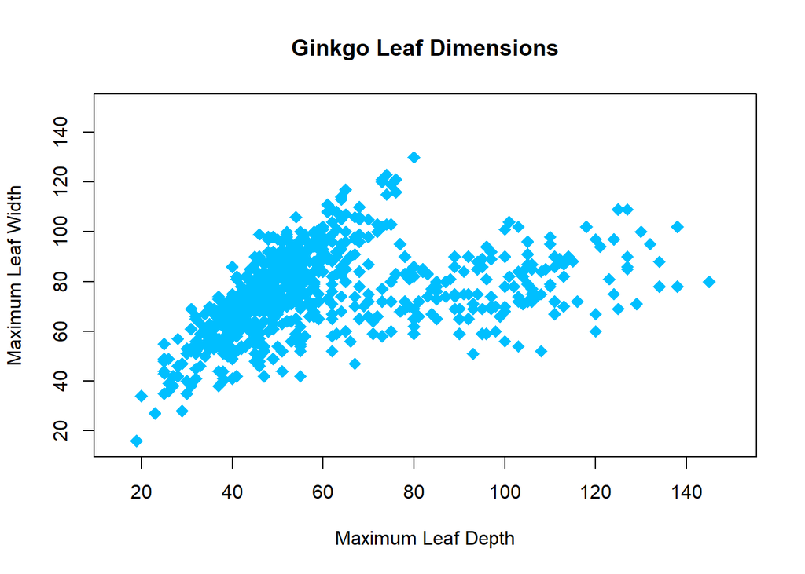

```r
plot(ginkgo$max_depth, ginkgo$max_width,
     xlab = "Maximum Leaf Depth",
     ylab = "Maximum Leaf Width",
     main = "Ginkgo Leaf Dimensions",
     xlim = c(15, 150),
     ylim = c(15, 150),
     col = "deepskyblue",
     pch = 18,
     cex = 1.5)
```

### Histograms

Another way to visualize data is with a histogram. Histograms display the spread of data points within a single column by plotting the data values on the x-axis and their frequency in the data set on the y-axis. Histograms can be easily created in R using the hist() function. hist() only requires the name of the column you wish to display, but can also accept an extra argument to specify the size of the “bins” the data are fitting into (breaks). Here’s an example of creating a histogram using our penguin data:

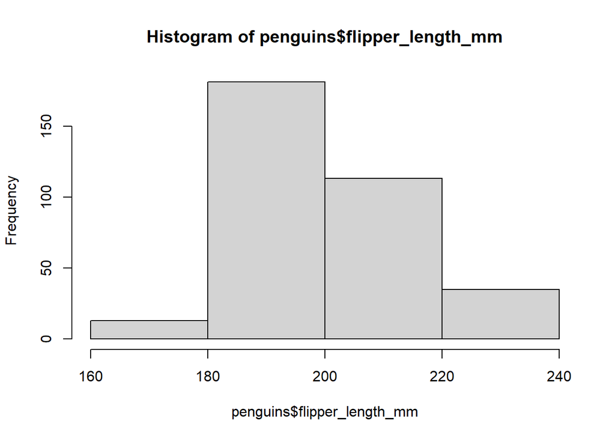

```r
# Notice how changing the number of breaks alters the number of bins the data are characterized into
hist(penguins$flipper_length_mm, breaks = 4)
```

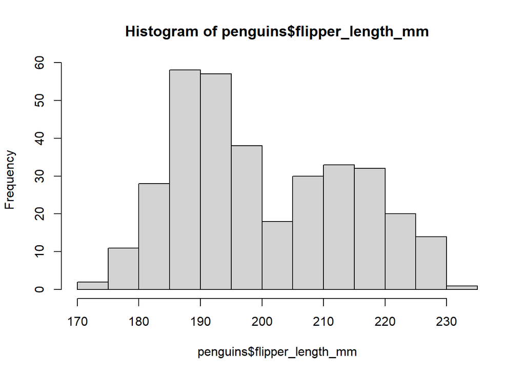

```r
hist(penguins$flipper_length_mm, breaks = 13)
```

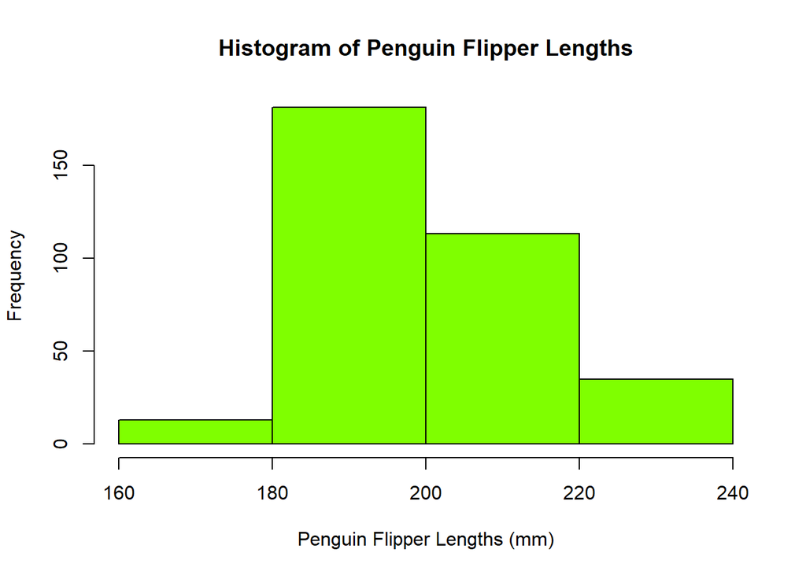

```r
# We can customize axes labels, titles, and colors just like we did with the scatterplot!
hist(penguins$flipper_length_mm, breaks = 4,
     main = "Histogram of Penguin Flipper Lengths",
     xlab = "Penguin Flipper Lengths (mm)",
     col = "chartreuse")
```

### Boxplots

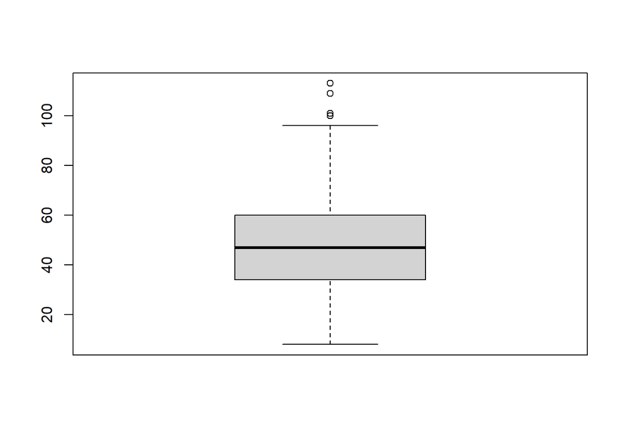

```r
# Basic boxplot of ginkgo petiole length, notice lines extending to
  #minimum and maximum values and points representing outliers
boxplot(ginkgo$petiole_length)
```

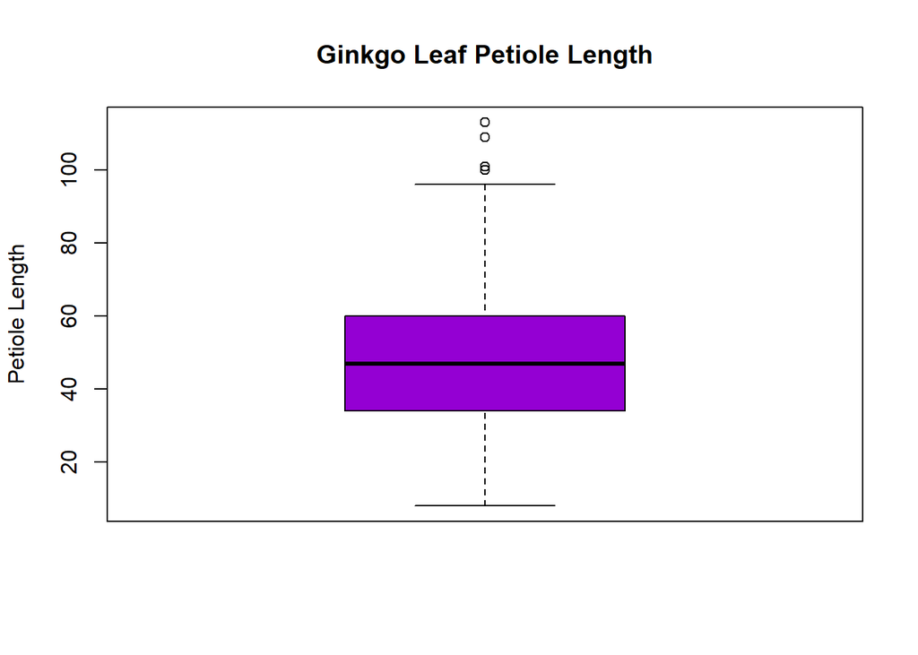

```r
# We can customize our boxplot just as we did with the other plots
boxplot(ginkgo$petiole_length,
        ylab = "Petiole Length",
        main = "Ginkgo Leaf Petiole Length",
        col = "darkviolet")
```

A boxplot can represent one column of data while being conditioned by another column. For instance, if we know that the shade provided by a tree was dependent on if it deciduous or coniferous, we would want to separate out our shade data based on the two types of trees. To condition a boxplot, we can simply alter the code used above by adding a “~” symbol followed by the column we want to condition the data. Here’s an example using our ginkgo data:

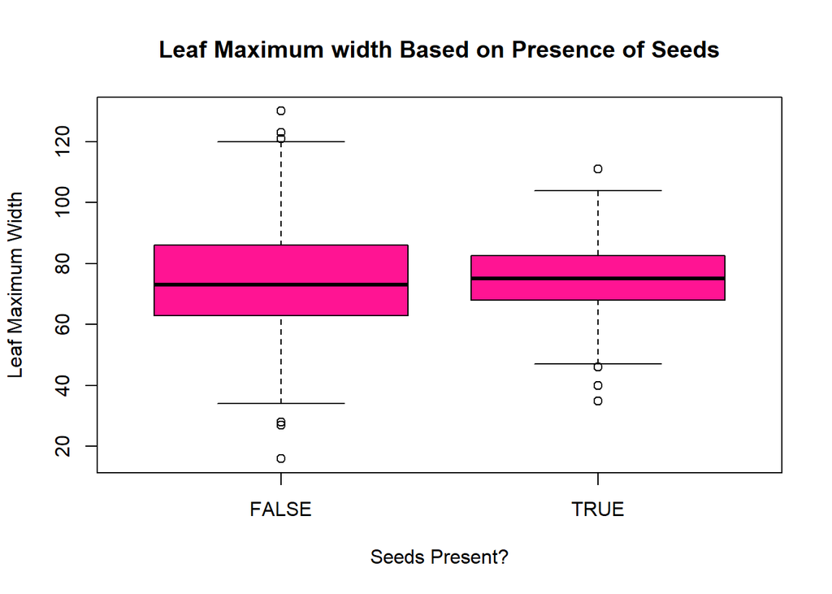

```r
boxplot(ginkgo$max_width ~ ginkgo$seeds_present,
        ylab = "Leaf Maximum Width",
        xlab = "Seeds Present?",
        main = "Leaf Maximum width Based on Presence of Seeds",
        col = "deeppink")
```

### Adding multiple plots to one window

When exploring data graphically, it can be helpful to look at more than one plot at once. We can add as many plots as we want to the viewing window using the par(mfrow) function. This function should be written on a line before your first plot and should include the number of plots you want in each column and row of the viewing window. For instance, if you want 4 plots in the window organized into 2 rows and 2 columns, you would write your code like this:

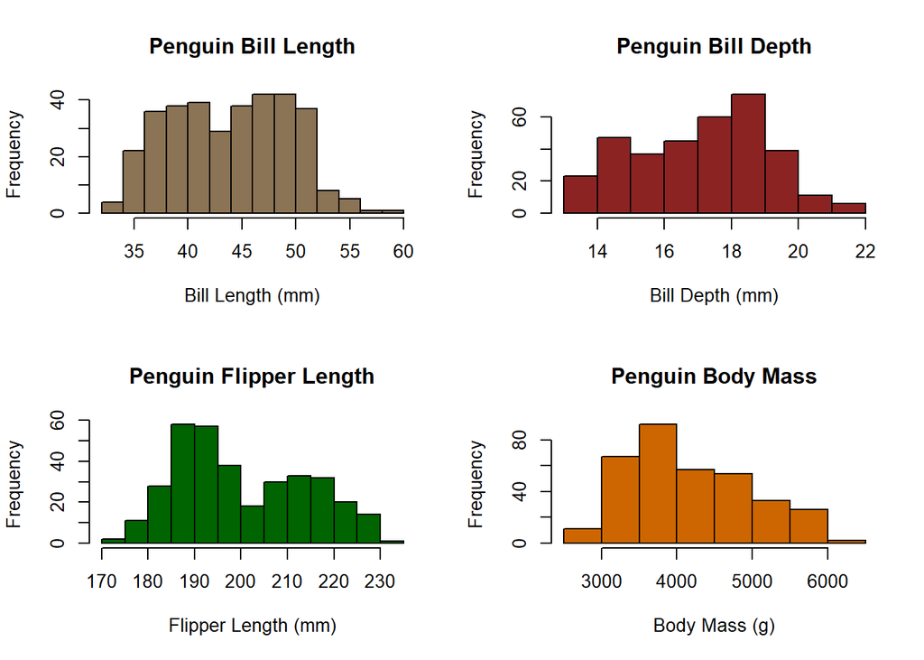

```r
par(mfrow = c(2,2))
hist(penguins$bill_length_mm, main = "Penguin Bill Length", xlab = "Bill Length (mm)", col = "burlywood4")
hist(penguins$bill_depth_mm, main = "Penguin Bill Depth", xlab = "Bill Depth (mm)", col = "brown4")
hist(penguins$flipper_length_mm, main = "Penguin Flipper Length", xlab = "Flipper Length (mm)", col = "darkgreen")
hist(penguins$body_mass_g, main = "Penguin Body Mass", xlab = "Body Mass (g)", col = "darkorange3")
```

We can re-arrange our plots by changing the number of rows and columns in our par(mfrow) function like this:

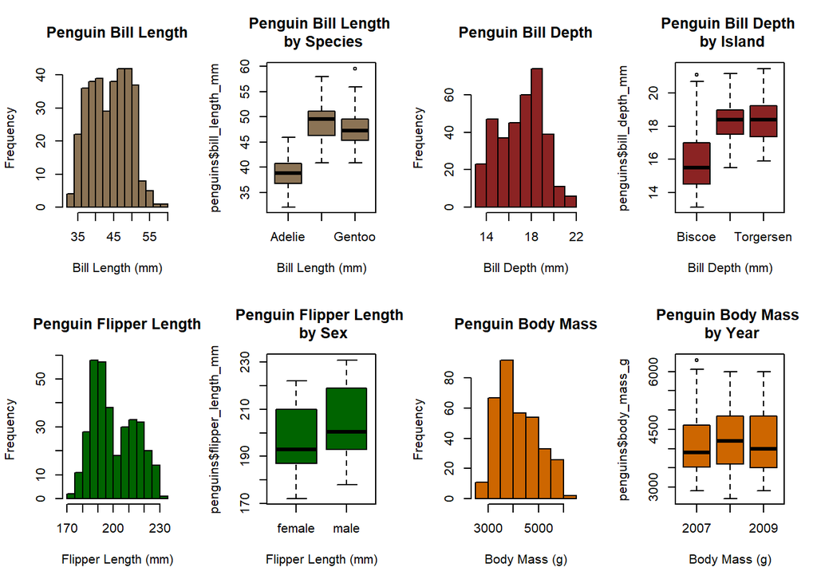

```r
par(mfrow = c(2,4))
hist(penguins$bill_length_mm, main = "Penguin Bill Length", xlab = "Bill Length (mm)", col = "burlywood4")
boxplot(penguins$bill_length_mm ~ penguins$species, main = "Penguin Bill Length \n by Species", xlab = "Bill Length (mm)", col = "burlywood4")

hist(penguins$bill_depth_mm, main = "Penguin Bill Depth", xlab = "Bill Depth (mm)", col = "brown4")
boxplot(penguins$bill_depth_mm ~ penguins$island, main = "Penguin Bill Depth \n by Island", xlab = "Bill Depth (mm)", col = "brown4")

hist(penguins$flipper_length_mm, main = "Penguin Flipper Length", xlab = "Flipper Length (mm)", col = "darkgreen")
boxplot(penguins$flipper_length_mm~ penguins$sex, main = "Penguin Flipper Length \n by Sex", xlab = "Flipper Length (mm)", col = "darkgreen")

hist(penguins$body_mass_g, main = "Penguin Body Mass", xlab = "Body Mass (g)", col = "darkorange3")
boxplot(penguins$body_mass_g ~ penguins$year, main = "Penguin Body Mass \n by Year", xlab = "Body Mass (g)", col = "darkorange3")
```

## Distribution Functions

Besides working with data collected in the field, we can also work with simulated data that follows one of our known distributions. R has many built-in distributions from which we can sample or simulate data. This data can be extremely helpful for testing whether observed data (data collected in the field) is significantly different than a distribution of data that may act as our null hypothesis distribution.

### The normal distribution

The normal distribution is based on two arguments (mean and standard deviation) and follows a bell-shaped curve with its peak at the mean and its spread based on the standard deviation. The larger the standard deviation, the wider the curve becomes, stretching the tails of the distribution. Changing the mean has no effect on the width of the distribution, but instead shifts the curve right or left.

The normal distribution is helpful for assessing the probability of choosing a particular value within the distribution. There are three ways we can look at this probability.

1. The probability of choosing that value exactly
2. The probability of choosing a sample that is less than or equal to that value
3. Having a probability in mind and calculating what value matches up with that probability

R is able to perform all of these probability calculations using separate functions. dnorm() will tell you what the probability is of sampling a single value from the normal distribution. For example, we may want to know what our probability is of getting a 90% on our statistics final by random chance. Let’s say the average grade for this final is an 80% and the standard deviation is 10% (most people score between a 60% and 100%) In that case, we would use the function dnorm() like this:

```r
# The probability of getting exactly 90% on your statistics final
dnorm(90, mean = 80, sd = 10)
```

```
## [1] 0.02419707
```

Knowing the probability of sampling an exact value can be useful in some cases, but often we want to know what the cumulative probability is (the probability of getting greater than or less than that specified value). Cumulative probability densities in R are calculated using the function pnorm(). If we want to see what our probability is of getting less than or equal to a 90% on our final, we can use the pnorm() function like this:

```r
# The probability of getting a 90 or less on the final
pnorm(90, mean = 80, sd = 10)
```

```
## [1] 0.8413447
```

pnorm() automatically calculates the probability of obtaining a sample that is less than or equal to our specified value, but can be adjusted to find a probability that we obtain a sample that is greater than or equal to our value (lower.tail = FALSE). We can also calculate this “upper tail” probability by simply taking 1 - lower tail probability. This is logical because the probability density of the entire distribution is 1, so subtracting a density from 1 simply provides the probability of getting a sample on the other side of your specified value.

Let’s use this logic to see what our probability is of getting a 90% or greater on the stats final:

```r
# We can use the lower.tail argument to see only the probability density in the upper tail like this:
pnorm(90, mean = 80, sd = 10, lower.tail = FALSE)
```

```
## [1] 0.1586553
```

```r
# Or we can simply subtract our probability density of receiving a grade =< 90% from 1 like this:
1 - pnorm(90, mean = 80, sd = 10)
```

```
## [1] 0.1586553
```

If we have a probability density in mind and want to see what value corresponds with that probability density, we can use the qnorm() function. The qnorm() function uses the probability density you provide it and returns a value at which the probability of sampling that value or less is your specified probability. For example, we can use the following code to see what grade the top 5% of students typically get on their stats final:

```r
# 95% of students achieve this grade or lower, so we know the top 5% of students achieve this grade or higher:
qnorm(0.95, mean = 80, sd = 10)
```

```
## [1] 96.44854
```

Besides predicting your grade on a stats final, this function can be extremely useful when testing for significance. For example, if we set an alpha significance value of p = 0.05, we essentially want our data to be outside of the main 95% of our distribution and can use qnorm() to find what values are outside of that 95%.

### The binomial distribution

Another distribution that can be helpful when simulating data is the binomial distribution. In many ways the binomial distribution is quite similar to the normal distribution, but the type of data is key to choosing the right distribution for your data. If your data consists of presence/absence, true/false, or short counts (mostly 0s and 1s), the binomial distribution might be the right fit!

The binomial distribution sees data as either a success or failure and can tell you the probability associated with a specified number of successes given the probability of success for each trial. For example, if we flip a coin and decide that each time we get heads is a success we can create a binomial distribution to predict the probability of getting heads a certain number of times.

Just like the normal distribution, R has three different functions to assess the probability associated with the binomial distribution:

1. The probability of getting an exact number of successes in a set number of trials
2. The probability of getting your number *or fewer* successes in a set number of trials
3. The number of trials you would get successes in given a set probability

The set-up is exactly the same as with the normal distribution, but with a slight change in the names of the functions. dbinom() (the binomial equivalent to dnorm) will return the probability of achieving an exact number of successes given a number of trials and the probability of success for each trial. For example, if we want to flip a coin 10 times and want to know the probability of getting 6 heads, we would write the code like this:

```r
# The probability of getting 6 heads out of 10 coin tosses (each toss has a 50:50 probability of heads vs. tails)
dbinom(6, size = 10, prob = 0.5)
```

```
## [1] 0.2050781
```

Just like with pnorm() for the normal distribution, we can use pbinom() to calculate the cumulative probability of achieving a set number *or fewer* successes within a set of trials. Let’s say we want to know the probability of getting 8 or fewer heads from flipping a coin 10 times:

```r
# The probability of getting 8 or fewer heads out of 10 coin flips
pbinom(8, size = 10, prob = 0.5)
```

```
## [1] 0.9892578
```

```r
pbinom(8, size = 10, prob = 0.5, lower.tail = FALSE)
```

```
## [1] 0.01074219
```

```r
1 - pbinom(8, size = 10, prob = 0.5)
```

```
## [1] 0.01074219
```

qnorm() also has a twin in the binomial distribution realm: qbinom()! qbinom() will take a probability you give it and tell you the number of successes you should have from a set number of trials. Let’s say we’re making a bet that we can guess the number of heads in a set of 10 coin tosses, but we’re going by the “Price is Right” rules where we can guess a value, but the actual number cannot exceed that value. We want to have 80% confidence that we’re going to win our bet, so we use qbinom() to see how many heads we should guess:

```r
# How many heads (or fewer) can we predict with 80% confidence we'll get when flipping a coin 10 times
qbinom(0.8, size = 10, prob = 0.5)
```

```
## [1] 6
```

```r
# From this output, we learn that we should bet that they'll get 6 or fewer heads in a set of 10 coin flips
```